# 3.2.2d_mtDNA_vs_nuclear_D3_distances

Else Mikkelsen

28/03/2022

This analysis aims to compare the mtDNA divergence between *S. pomarinus* and *S. skua* with the nuclear divergence. Is the mtDNA divergence shallower than expected, or is it within the distribution that we see in the nuclear genome? Since mtDNA and nuclear DNA have very different mutation rates, I am standardizing all divergence estimates by dividing them by the divergence between *S. pomarinus* and the small jaegers, to get a measure of relative divergence.

First, I load some functions that I wrote to process the data. Note that some aspects are hard-coded for my particular dataset because the order of the columns is otherwise difficult to predict.

```r
#load distance data
load_distance <- function(file){
  #read in the distance matrix
  dists <- read.delim(file, sep="\t", header=F) #kimura 2-parameter distances
  #dists <- vroom("allwindows.distmat", delim="\t", col_names=F) #faster way to read the data, but changes col names a bit

  #remove empty columns
  emptycols <- sapply(dists, function (k) all(is.na(k))) #get a list of the columns that are empty
  dists <- dists[!emptycols] #keep only the columns that are NOT empty
  distsf <- dists[sapply(dists, is.numeric)]
  #Now select the data that you are interested to plot. This requires manually determining which column contains your distance of interest.
  dists_select <- NULL #start at empty dataframe
  dists_select$locus <- dists$V1 #This column should contain the locus names
  #Now manually specify the names of each comparison
  dists_select$Alca_torda__Alca_torda <- distsf[,1]
  dists_select$ANSK01__Alca_torda <- distsf[,2]
  dists_select$ANSK7__Alca_torda <- distsf[,3]
  dists_select$ANSK8__Alca_torda <- distsf[,4]
  dists_select$Alca_torda__CHSK_MKP2451 <- distsf[,5]
  dists_select$Alca_torda__CISK2 <- distsf[,6]
  dists_select$Alca_torda__CISK3 <- distsf[,7]
  dists_select$Alca_torda__CISK55 <- distsf[,8]
  dists_select$Alca_torda__Fratercula_arctica <- distsf[,9]
  dists_select$Alca_torda__GRSK_MKP1592 <- distsf[,10]
  dists_select$Alca_torda__GRSK_MKP1593 <- distsf[,11]
  dists_select$Alca_torda__LTJA_MKP990 <- distsf[,12]
  dists_select$Alca_torda__PAJA_B20730 <- distsf[,13]
  dists_select$Alca_torda__PAJA_USNM606730 <- distsf[,14]
  dists_select$Alca_torda__POJA_4 <- distsf[,15]
  dists_select$Alca_torda__POJA_IB2659 <- distsf[,16]
  dists_select$Alca_torda__POJA_MKP1559 <- distsf[,17]
  dists_select$Alca_torda__Uria_lomvia <- distsf[,18]
  dists_select$ANSK01__ANSK01 <- distsf[,19]
  dists_select$ANSK01__ANSK7 <- distsf[,20]
  dists_select$ANSK01__ANSK8 <- distsf[,21]
  dists_select$ANSK01__CHSK_MKP2451 <- distsf[,22]
  dists_select$ANSK01__CISK2 <- distsf[,23]
  dists_select$ANSK01__CISK3 <- distsf[,24]
  dists_select$ANSK01__CISK55 <- distsf[,25]
  dists_select$ANSK01__Fratercula_arctica <- distsf[,26]
  dists_select$ANSK01__GRSK_MKP1592 <- distsf[,27]
  dists_select$ANSK01__GRSK_MKP1593 <- distsf[,28]
  dists_select$ANSK01__LTJA_MKP990 <- distsf[,29]
  dists_select$ANSK01__PAJA_B20730 <- distsf[,30]
  dists_select$ANSK01__PAJA_USNM606730 <- distsf[,31]
  dists_select$ANSK01__POJA_4 <- distsf[,32]
  dists_select$ANSK01__POJA_IB2659 <- distsf[,33]
  dists_select$ANSK01__POJA_MKP1559 <- distsf[,34]
  dists_select$ANSK01__Uria_lomvia <- distsf[,35]
  dists_select$ANSK7__ANSK7 <- distsf[,36]
  dists_select$ANSK7__ANSK8 <- distsf[,37]
  dists_select$ANSK7__CHSK_MKP2451 <- distsf[,38]
  dists_select$ANSK7__CISK2 <- distsf[,39]
  dists_select$ANSK7__CISK3 <- distsf[,40]
  dists_select$ANSK7__CISK55 <- distsf[,41]
  dists_select$ANSK7__Fratercula_arctica <- distsf[,42]
  dists_select$ANSK7__GRSK_MKP1592 <- distsf[,43]
  dists_select$ANSK7__GRSK_MKP1593 <- distsf[,44]
  dists_select$ANSK7__LTJA_MKP990 <- distsf[,45]
  dists_select$ANSK7__PAJA_B20730 <- distsf[,46]
  dists_select$ANSK7__PAJA_USNM606730 <- distsf[,47]
  dists_select$ANSK7__POJA_4 <- distsf[,48]
  dists_select$ANSK7__POJA_IB2659 <- distsf[,49]
  dists_select$ANSK7__POJA_MKP1559 <- distsf[,50]
  dists_select$ANSK7__Uria_lomvia <- distsf[,51]
  dists_select$ANSK8__ANSK8 <- distsf[,52]
  dists_select$ANSK8__CHSK_MKP2451 <- distsf[,53]
  dists_select$ANSK8__CISK2 <- distsf[,54]
  dists_select$ANSK8__CISK3 <- distsf[,55]
  dists_select$ANSK8__CISK55 <- distsf[,56]
  dists_select$ANSK8__Fratercula_arctica <- distsf[,57]
  dists_select$ANSK8__GRSK_MKP1592 <- distsf[,58]
  dists_select$ANSK8__GRSK_MKP1593 <- distsf[,59]
  dists_select$ANSK8__LTJA_MKP990 <- distsf[,60]
  dists_select$ANSK8__PAJA_B20730 <- distsf[,61]
  dists_select$ANSK8__PAJA_USNM606730 <- distsf[,62]
  dists_select$ANSK8__POJA_4 <- distsf[,63]
  dists_select$ANSK8__POJA_IB2659 <- distsf[,64]
  dists_select$ANSK8__POJA_MKP1559 <- distsf[,65]
  dists_select$ANSK8__Uria_lomvia <- distsf[,66]
  dists_select$CHSK_MKP2451__CHSK_MKP2451 <- distsf[,67]
  dists_select$CHSK_MKP2451__CISK2 <- distsf[,68]
  dists_select$CHSK_MKP2451__CISK3 <- distsf[,69]
  dists_select$CHSK_MKP2451__CISK55 <- distsf[,70]
  dists_select$CHSK_MKP2451__Fratercula_arctica <- distsf[,71]
  dists_select$CHSK_MKP2451__GRSK_MKP1592 <- distsf[,72]
  dists_select$CHSK_MKP2451__GRSK_MKP1593 <- distsf[,73]
  dists_select$CHSK_MKP2451__LTJA_MKP990 <- distsf[,74]
  dists_select$CHSK_MKP2451__PAJA_B20730 <- distsf[,75]
  dists_select$CHSK_MKP2451__PAJA_USNM606730 <- distsf[,76]
  dists_select$CHSK_MKP2451__POJA_4 <- distsf[,77]
  dists_select$CHSK_MKP2451__POJA_IB2659 <- distsf[,78]
  dists_select$CHSK_MKP2451__POJA_MKP1559 <- distsf[,79]
  dists_select$CHSK_MKP2451__Uria_lomvia <- distsf[,80]
  dists_select$CISK2__CISK2 <- distsf[,81]
  dists_select$CISK2__CISK3 <- distsf[,82]
  dists_select$CISK2__CISK55 <- distsf[,83]
  dists_select$CISK2__Fratercula_arctica <- distsf[,84]
  dists_select$CISK2__GRSK_MKP1592 <- distsf[,85]
  dists_select$CISK2__GRSK_MKP1593 <- distsf[,86]
  dists_select$CISK2__LTJA_MKP990 <- distsf[,87]
  dists_select$CISK2__PAJA_B20730 <- distsf[,88]
  dists_select$CISK2__PAJA_USNM606730 <- distsf[,89]
  dists_select$CISK2__POJA_4 <- distsf[,90]
  dists_select$CISK2__POJA_IB2659 <- distsf[,91]
  dists_select$CISK2__POJA_MKP1559 <- distsf[,92]
  dists_select$CISK2__Uria_lomvia <- distsf[,93]
  dists_select$CISK3__CISK3 <- distsf[,94]
  dists_select$CISK3__CISK55 <- distsf[,95]
  dists_select$CISK3__Fratercula_arctica <- distsf[,96]
  dists_select$CISK3__GRSK_MKP1592 <- distsf[,97]
  dists_select$CISK3__GRSK_MKP1593 <- distsf[,98]
  dists_select$CISK3__LTJA_MKP990 <- distsf[,99]
  dists_select$CISK3__PAJA_B20730 <- distsf[,100]
  dists_select$CISK3__PAJA_USNM606730 <- distsf[,101]
  dists_select$CISK3__POJA_4 <- distsf[,102]
  dists_select$CISK3__POJA_IB2659 <- distsf[,103]
  dists_select$CISK3__POJA_MKP1559 <- distsf[,104]
  dists_select$CISK3__Uria_lomvia <- distsf[,105]
  dists_select$CISK55__CISK55 <- distsf[,106]
  dists_select$CISK55__Fratercula_arctica <- distsf[,107]
  dists_select$CISK55__GRSK_MKP1592 <- distsf[,108]
  dists_select$CISK55__GRSK_MKP1593 <- distsf[,109]
  dists_select$CISK55__LTJA_MKP990 <- distsf[,110]
  dists_select$CISK55__PAJA_B20730 <- distsf[,111]
  dists_select$CISK55__PAJA_USNM606730 <- distsf[,112]
  dists_select$CISK55__POJA_4 <- distsf[,113]
  dists_select$CISK55__POJA_IB2659 <- distsf[,114]
  dists_select$CISK55__POJA_MKP1559 <- distsf[,115]
  dists_select$CISK55__Uria_lomvia <- distsf[,116]
  dists_select$Fratercula_arctica__Fratercula_arctica <- distsf[,117]
  dists_select$Fratercula_arctica__GRSK_MKP1592 <- distsf[,118]
  dists_select$Fratercula_arctica__GRSK_MKP1593 <- distsf[,119]
  dists_select$Fratercula_arctica__LTJA_MKP990 <- distsf[,120]
  dists_select$Fratercula_arctica__PAJA_B20730 <- distsf[,121]
  dists_select$Fratercula_arctica__PAJA_USNM606730 <- distsf[,122]
  dists_select$Fratercula_arctica__POJA_4 <- distsf[,123]
  dists_select$Fratercula_arctica__POJA_IB2659 <- distsf[,124]
  dists_select$Fratercula_arctica__POJA_MKP1559 <- distsf[,125]
  dists_select$Fratercula_arctica__Uria_lomvia <- distsf[,126]
  dists_select$GRSK_MKP1592__GRSK_MKP1592 <- distsf[,127]
  dists_select$GRSK_MKP1592__GRSK_MKP1593 <- distsf[,128]
  dists_select$GRSK_MKP1592__LTJA_MKP990 <- distsf[,129]
  dists_select$GRSK_MKP1592__PAJA_B20730 <- distsf[,130]
  dists_select$GRSK_MKP1592__PAJA_USNM606730 <- distsf[,131]
  dists_select$GRSK_MKP1592__POJA_4 <- distsf[,132]
  dists_select$GRSK_MKP1592__POJA_IB2659 <- distsf[,133]
  dists_select$GRSK_MKP1592__POJA_MKP1559 <- distsf[,134]
  dists_select$GRSK_MKP1592__Uria_lomvia <- distsf[,135]
  dists_select$GRSK_MKP1593__GRSK_MKP1593 <- distsf[,136]
  dists_select$GRSK_MKP1593__LTJA_MKP990 <- distsf[,137]
  dists_select$GRSK_MKP1593__PAJA_B20730 <- distsf[,138]
  dists_select$GRSK_MKP1593__PAJA_USNM606730 <- distsf[,139]
  dists_select$GRSK_MKP1593__POJA_4 <- distsf[,140]
  dists_select$GRSK_MKP1593__POJA_IB2659 <- distsf[,141]
  dists_select$GRSK_MKP1593__POJA_MKP1559 <- distsf[,142]
  dists_select$GRSK_MKP1593__Uria_lomvia <- distsf[,143]
  dists_select$LTJA_MKP990__LTJA_MKP990 <- distsf[,144]
  dists_select$LTJA_MKP990__PAJA_B20730 <- distsf[,145]
  dists_select$LTJA_MKP990__PAJA_USNM606730 <- distsf[,146]
  dists_select$LTJA_MKP990__POJA_4 <- distsf[,147]
  dists_select$LTJA_MKP990__POJA_IB2659 <- distsf[,148]
  dists_select$LTJA_MKP990__POJA_MKP1559 <- distsf[,149]
  dists_select$LTJA_MKP990__Uria_lomvia <- distsf[,150]
  dists_select$PAJA_B20730__PAJA_B20730 <- distsf[,151]
  dists_select$PAJA_B20730__PAJA_USNM606730 <- distsf[,152]
  dists_select$PAJA_B20730__POJA_4 <- distsf[,153]
  dists_select$PAJA_B20730__POJA_IB2659 <- distsf[,154]
  dists_select$PAJA_B20730__POJA_MKP1559 <- distsf[,155]
  dists_select$PAJA_B20730__Uria_lomvia <- distsf[,156]
  dists_select$PAJA_USNM606730__PAJA_USNM606730 <- distsf[,157]
  dists_select$PAJA_USNM606730__POJA_4 <- distsf[,158]
  dists_select$PAJA_USNM606730__POJA_IB2659 <- distsf[,159]
  dists_select$PAJA_USNM606730__POJA_MKP1559 <- distsf[,160]
  dists_select$PAJA_USNM606730__Uria_lomvia <- distsf[,161]
  dists_select$POJA_4__POJA_4 <- distsf[,162]
  dists_select$POJA_4__POJA_IB2659 <- distsf[,163]
  dists_select$POJA_4__POJA_MKP1559 <- distsf[,164]
  dists_select$POJA_4__Uria_lomvia <- distsf[,165]
  dists_select$POJA_IB2659__POJA_IB2659 <- distsf[,166]
  dists_select$POJA_IB2659__POJA_MKP1559 <- distsf[,167]
  dists_select$POJA_IB2659__Uria_lomvia <- distsf[,168]
  dists_select$POJA_MKP1559__POJA_MKP1559 <- distsf[,169]
  dists_select$POJA_MKP1559__Uria_lomvia <- distsf[,170]
```

```r
  dists_select <- as.data.frame(dists_select) %>%
       separate(locus, c("chromosome", "start", "end"), "_")
  return(dists_select)
}

#load missingness matrix
load_missingness <- function(file) {
  #dataset <- read.delim(file, sep="\t", header=F) #read the data
  dataset <- vroom(file, delim="\t", col_names=F, skip = 0) #read the data
  formatted <- as_tibble(t(dataset)) %>% #transpose rows to columns
  rename(locus = V1, Alca_torda = V2, ANSK01 = V3, ANSK7 = V4, ANSK8 = V5, CHSK_MKP2451 = V6, CISK2 = V7, CISK3 = V8, CISK55 = V9, Fratercula_arctica = V10, GRSK_MKP1592 = V11, GRSK_MKP1593 = V12, LTJA_MKP990 = V13, PAJA_B20730 = V14, PAJA_USNM606730 = V15, POJA_4 = V16, POJA_IB2659 = V17, POJA_MKP1559 = V18, Uria_lomvia = V19) %>% #rename columns
      mutate(locus = str_replace(locus, "^.*/", ""))  %>% #remove file path from locus name
     separate(locus, c("chromosome", "start", "end"), "_") #split chromosome from position
  return(formatted)
}

#standardize the divergence estimates
make_mttest <- function(dists_selecte_mtchunks){
   #First, calculate distance between POJA/CHSK standardized by POJA/LTJA
   dists_mttest <- NULL
   dists_mttest$chromosome <- dists_selecte_mtchunks$chromosome
   dists_mttest$start <- dists_selecte_mtchunks$start
   dists_mttest$end <- dists_selecte_mtchunks$end

    dists_mttest$ANSK7__POJA_4.cor <- dists_selecte_mtchunks$ANSK7__POJA_4/dists_selecte_mtchunks$PAJA_B20730__POJA_4
    dists_mttest$ANSK7__POJA_IB2659.cor <- dists_selecte_mtchunks$ANSK7__POJA_IB2659/dists_selecte_mtchunks$PAJA_B20730__POJA_IB2659
    dists_mttest$ANSK7__POJA_MKP1559.cor <- dists_selecte_mtchunks$ANSK7__POJA_MKP1559/dists_selecte_mtchunks$PAJA_B20730__POJA_MKP1559
    dists_mttest$ANSK8__POJA_4.cor <- dists_selecte_mtchunks$ANSK8__POJA_4/dists_selecte_mtchunks$PAJA_B20730__POJA_4
    dists_mttest$ANSK8__POJA_IB2659.cor <- dists_selecte_mtchunks$ANSK8__POJA_IB2659/dists_selecte_mtchunks$PAJA_B20730__POJA_IB2659
    dists_mttest$ANSK8__POJA_MKP1559.cor <- dists_selecte_mtchunks$ANSK8__POJA_MKP1559/dists_selecte_mtchunks$PAJA_B20730__POJA_MKP1559
    dists_mttest$ANSK01__POJA_4.cor <- dists_selecte_mtchunks$ANSK01__POJA_4/dists_selecte_mtchunks$PAJA_B20730__POJA_4
    dists_mttest$ANSK01__POJA_IB2659.cor <- dists_selecte_mtchunks$ANSK01__POJA_IB2659/dists_selecte_mtchunks$PAJA_B20730__POJA_IB2659
    dists_mttest$ANSK01__POJA_MKP1559.cor <- dists_selecte_mtchunks$ANSK01__POJA_MKP1559/dists_selecte_mtchunks$PAJA_B20730__POJA_MKP1559
    dists_mttest$CISK2__POJA_4.cor <- dists_selecte_mtchunks$CISK2__POJA_4/dists_selecte_mtchunks$PAJA_B20730__POJA_4
    dists_mttest$CISK2__POJA_IB2659.cor <- dists_selecte_mtchunks$CISK2__POJA_IB2659/dists_selecte_mtchunks$PAJA_B20730__POJA_IB2659
    dists_mttest$CISK2__POJA_MKP1559.cor <- dists_selecte_mtchunks$CISK2__POJA_MKP1559/dists_selecte_mtchunks$PAJA_B20730__POJA_MKP1559
    dists_mttest$CISK3__POJA_4.cor <- dists_selecte_mtchunks$CISK3__POJA_4/dists_selecte_mtchunks$PAJA_B20730__POJA_4
    dists_mttest$CISK3__POJA_IB2659.cor <- dists_selecte_mtchunks$CISK3__POJA_IB2659/dists_selecte_mtchunks$PAJA_B20730__POJA_IB2659
    dists_mttest$CISK3__POJA_MKP1559.cor <- dists_selecte_mtchunks$CISK3__POJA_MKP1559/dists_selecte_mtchunks$PAJA_B20730__POJA_MKP1559
    dists_mttest$CISK55__POJA_4.cor <- dists_selecte_mtchunks$CISK55__POJA_4/dists_selecte_mtchunks$PAJA_B20730__POJA_4
    dists_mttest$CISK55__POJA_IB2659.cor <- dists_selecte_mtchunks$CISK55__POJA_IB2659/dists_selecte_mtchunks$PAJA_B20730__POJA_IB2659
    dists_mttest$CISK55__POJA_MKP1559.cor <- dists_selecte_mtchunks$CISK55__POJA_MKP1559/dists_selecte_mtchunks$PAJA_B20730__POJA_MKP1559
    dists_mttest$CHSK_MKP2451__POJA_4.cor <- dists_selecte_mtchunks$CHSK_MKP2451__POJA_4/dists_selecte_mtchunks$PAJA_B20730__POJA_4
    dists_mttest$CHSK_MKP2451__POJA_IB2659.cor <- dists_selecte_mtchunks$CHSK_MKP2451__POJA_IB2659/dists_selecte_mtchunks$PAJA_B20730__POJA_IB2659
    dists_mttest$CHSK_MKP2451__POJA_MKP1559.cor <- dists_selecte_mtchunks$CHSK_MKP2451__POJA_MKP1559/dists_selecte_mtchunks$PAJA_B20730__POJA_MKP1559
    dists_mttest$GRSK_MKP1592__POJA_4.cor <- dists_selecte_mtchunks$GRSK_MKP1592__POJA_4/dists_selecte_mtchunks$PAJA_B20730__POJA_4
    dists_mttest$GRSK_MKP1592__POJA_IB2659.cor <- dists_selecte_mtchunks$GRSK_MKP1592__POJA_IB2659/dists_selecte_mtchunks$PAJA_B20730__POJA_IB2659
    dists_mttest$GRSK_MKP1592__POJA_MKP1559.cor <- dists_selecte_mtchunks$GRSK_MKP1592__POJA_MKP1559/dists_selecte_mtchunks$PAJA_B20730__POJA_MKP1559
    dists_mttest$GRSK_MKP1593__POJA_4.cor <- dists_selecte_mtchunks$GRSK_MKP1593__POJA_4/dists_selecte_mtchunks$PAJA_B20730__POJA_4
    dists_mttest$GRSK_MKP1593__POJA_IB2659.cor <- dists_selecte_mtchunks$GRSK_MKP1593__POJA_IB2659/dists_selecte_mtchunks$PAJA_B20730__POJA_IB2659
    dists_mttest$GRSK_MKP1593__POJA_MKP1559.cor <- dists_selecte_mtchunks$GRSK_MKP1593__POJA_MKP1559/dists_selecte_mtchunks$PAJA_B20730__POJA_MKP1559
  dists_mttest$ANSK01__GRSK_MKP1592.cor <-   dists_selecte_mtchunks$ANSK01__GRSK_MKP1592/dists_selecte_mtchunks$PAJA_B20730__POJA_4
  dists_mttest$ANSK01__GRSK_MKP1593.cor <-   dists_selecte_mtchunks$ANSK01__GRSK_MKP1593/dists_selecte_mtchunks$PAJA_B20730__POJA_4
  dists_mttest$ANSK7__GRSK_MKP1592.cor <-   dists_selecte_mtchunks$ANSK7__GRSK_MKP1592/dists_selecte_mtchunks$PAJA_B20730__POJA_4
  dists_mttest$ANSK7__GRSK_MKP1593.cor <-   dists_selecte_mtchunks$ANSK7__GRSK_MKP1593/dists_selecte_mtchunks$PAJA_B20730__POJA_4
  dists_mttest$ANSK8__GRSK_MKP1592.cor <-   dists_selecte_mtchunks$ANSK8__GRSK_MKP1592/dists_selecte_mtchunks$PAJA_B20730__POJA_4
  dists_mttest$ANSK8__GRSK_MKP1593.cor <-   dists_selecte_mtchunks$ANSK8__GRSK_MKP1593/dists_selecte_mtchunks$PAJA_B20730__POJA_4
  dists_mttest$CHSK_MKP2451__GRSK_MKP1592.cor <-   dists_selecte_mtchunks$CHSK_MKP2451__GRSK_MKP1592/dists_selecte_mtchunks$PAJA_B20730__POJA_4
  dists_mttest$CHSK_MKP2451__GRSK_MKP1593.cor <-   dists_selecte_mtchunks$CHSK_MKP2451__GRSK_MKP1593/dists_selecte_mtchunks$PAJA_B20730__POJA_4
  dists_mttest$CISK2__GRSK_MKP1592.cor <-   dists_selecte_mtchunks$CISK2__GRSK_MKP1592/dists_selecte_mtchunks$PAJA_B20730__POJA_4
  dists_mttest$CISK2__GRSK_MKP1593.cor <-   dists_selecte_mtchunks$CISK2__GRSK_MKP1593/dists_selecte_mtchunks$PAJA_B20730__POJA_4
  dists_mttest$CISK3__GRSK_MKP1592.cor <-   dists_selecte_mtchunks$CISK3__GRSK_MKP1592/dists_selecte_mtchunks$PAJA_B20730__POJA_4
  dists_mttest$CISK3__GRSK_MKP1593.cor <-   dists_selecte_mtchunks$CISK3__GRSK_MKP1593/dists_selecte_mtchunks$PAJA_B20730__POJA_4
  dists_mttest$CISK55__GRSK_MKP1592.cor <-    dists_selecte_mtchunks$CISK55__GRSK_MKP1592/dists_selecte_mtchunks$PAJA_B20730__POJA_4
  dists_mttest$CISK55__GRSK_MKP1593.cor <-    dists_selecte_mtchunks$CISK55__GRSK_MKP1593/dists_selecte_mtchunks$PAJA_B20730__POJA_4
  dists_mttest$GRSK_MKP1592__GRSK_MKP1592.cor <-    dists_selecte_mtchunks$GRSK_MKP1592__GRSK_MKP1592/dists_selecte_mtchunks$PAJA_B20730__POJA_4
  dists_mttest$GRSK_MKP1592__GRSK_MKP1593.cor <-    dists_selecte_mtchunks$GRSK_MKP1592__GRSK_MKP1593/dists_selecte_mtchunks$PAJA_B20730__POJA_4
  dists_mttest$GRSK_MKP1593__GRSK_MKP1593.cor <-    dists_selecte_mtchunks$GRSK_MKP1593__GRSK_MKP1593/dists_selecte_mtchunks$PAJA_B20730__POJA_4
    dists_mttest <- as.data.frame(dists_mttest)
    return(dists_mttest)
}
```

Next, I load the data.

```r
#load the data
dists_selecte_mtchunks <- load_distance("17kbwindows.distmat")

#load missingness
missingness <- load_missingness("chunk.missingness")

#merge distances and missingness into a single dataframe
dists_select_mtchunks <- merge(dists_selecte_mtchunks, as.data.frame(missingness), by=c("chromosome","start", "end"))
#filter the dataset by removing sites that have more than 1002 bp missing data in any focal sample (Catharacta, S. pomarinus, PAJA_B20730)
dists_select_mtchunks <- dists_select_mtchunks %>%
  filter(as.numeric(ANSK01)<1002 & as.numeric(ANSK7)<1002 & as.numeric(ANSK8)<1002 & as.numeric(CISK3)<1002 & as.numeric(CISK55)<1002 & as.numeric(CISK2)<1002 & as.numeric(GRSK_MKP1592)<1002 & as.numeric(GRSK_MKP1593)<1002 & as.numeric(CHSK_MKP2451)<1002 & as.numeric(POJA_4)<1002 & as.numeric(POJA_MKP1559)<1002 & as.numeric(POJA_IB2659)<1002 & as.numeric(PAJA_B20730)<1002)

#format the data
dists_mttest <- make_mttest(dists_select_mtchunks)
```

## Calculate relative mtDNA divergences

Now, I am making two vectors to hold the mtDNA relative divergences. The first is 21 estimates of relative divergence between *S. pomarinus* and the southern hemisphere skuas (3 *S. pomarinus* times 7 Southern skuas). The next is 6 estimates of relative divergence between *S. pomarinus* and *S. skua* (3 *S. pomarinus* times 2 *S. skua*).

```r
pomarinus_vs_southern <- as.numeric(c("0.167657551", "0.168846611", "0.171224732", "0.161712247", "0.171224732", "0.171224732", "0.172413793", "0.158463385", "0.162064826", "0.164465786", "0.153661465", "0.163265306", "0.163265306", "0.164465786", "0.157451923", "0.158653846", "0.161057692", "0.155048077", "0.161057692", "0.161057692", "0.162259615"))
pomarinus_vs_Sskua <- as.numeric(c("0.07372176", "0.076099881", "0.068427371", "0.070828331", "0.064903846", "0.066105769"))
pomarinus_vs_southern_mean <- mean(pomarinus_vs_southern)
pomarinus_vs_Sskua_mean <- mean(pomarinus_vs_Sskua)

pomarinus_vs_southern_mean
```

```
## [1] 0.1633592
```

```r
pomarinus_vs_Sskua_mean
```

```
## [1] 0.07001449
```

The mitochondrial divergence between *S. pomarinus* and *S. skua* is much lower than between *S. pomarinus* and the southern hemisphere *Catharacta*.

## Plot nuclear divergence distributions

Next, I can look at the distributions of relative divergence for various combinations of taxa. I want to ensure that these distributions are not different depending on which *S. pomarinus* sample I am looking at, and that none of the samples have shifted distributions. They all look the same. Note that they might not all look the same if I had not filtered the blocks for missing data.

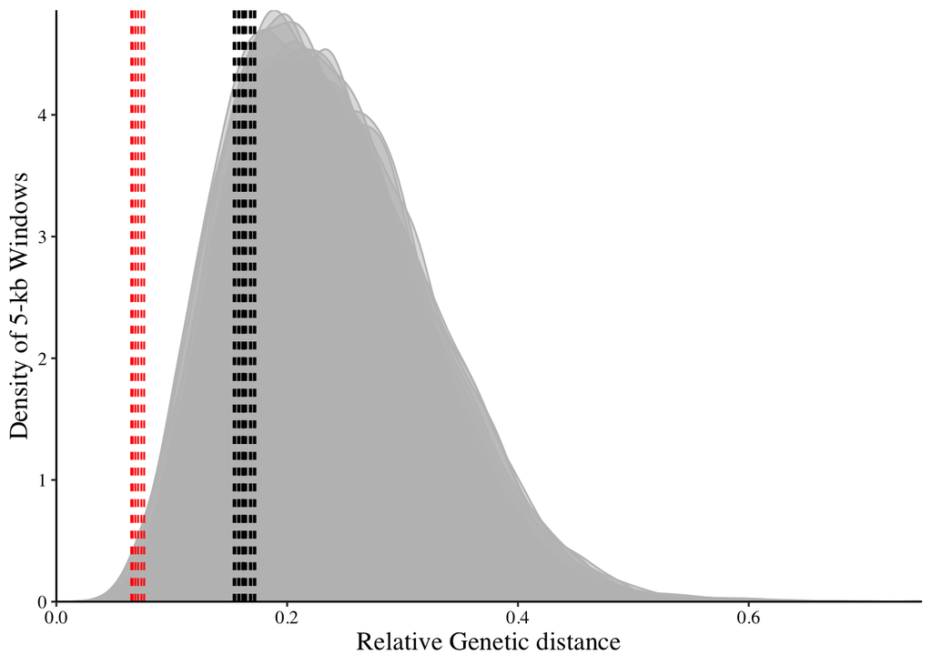

```r
#select the pair of interest to plot
#selected_pairs <- c("ANSK7__POJA_4.cor", "ANSK8__POJA_4.cor", "ANSK01__POJA_4.cor", "CISK2__POJA_4.cor", "CISK3__POJA_4.cor", "CISK55__POJA_4.cor", "CHSK_MKP2451__POJA_4.cor", "GRSK_MKP1592__POJA_4.cor", "GRSK_MKP1593__POJA_4.cor")
#selected_pairs <- c("ANSK7__POJA_IB2659.cor", "ANSK8__POJA_IB2659.cor", "ANSK01__POJA_IB2659.cor", "CISK2__POJA_IB2659.cor", "CISK3__POJA_IB2659.cor", "CISK55__POJA_IB2659.cor", "CHSK_MKP2451__POJA_IB2659.cor", "GRSK_MKP1592__POJA_IB2659.cor", "GRSK_MKP1593__POJA_IB2659.cor")
selected_pairs <- c( "ANSK7__POJA_MKP1559.cor", "ANSK8__POJA_MKP1559.cor", "ANSK01__POJA_MKP1559.cor", "CISK2__POJA_MKP1559.cor", "CISK3__POJA_MKP1559.cor", "CISK55__POJA_MKP1559.cor", "CHSK_MKP2451__POJA_MKP1559.cor", "GRSK_MKP1592__POJA_MKP1559.cor", "GRSK_MKP1593__POJA_MKP1559.cor")


#Then, plot these distributions
as.data.frame(dists_mttest) %>%
      tidyr::gather("pair", "distance", 4:length(dists_mttest)) %>%
      filter(pair %in% selected_pairs) %>% #
      filter(!grepl('chrZ', chromosome)) %>% #remove chrZ, since it might have different dynamics than autosomes
      ggplot(aes(xcolor = pair))+
      geom_density(aes(x=distance),alpha=0.5,colour="gray75", fill="gray75")+
      theme_classic()+ #simplify plot
      theme(axis.text.y = element_text(family="Times", face="plain", colour="black", size=10), axis.text.x = element_text(family="Times", face="plain", colour="black", size=10), axis.title.x = element_text(family="Times", face="plain", colour="black", size=14), axis.title.y = element_text(family="Times", face="plain", colour="black", size=14), legend.text = element_text(family="Times", face="italic", colour="black", size=10), legend.title = element_text(family="Times", face="plain", colour="black", size=12))+
      scale_x_continuous(expand = c(0, 0), limits = c(0, 0.75)) + #make sure that the origin is at 0,0
      scale_y_continuous(expand = c(0, 0), limits = c(0, NA))+
      xlab("Relative Genetic distance")+
      ylab("Density of 5-kb Windows")+
      geom_vline(xintercept = pomarinus_vs_southern, linetype="dashed", color = "black")+ #add a horizonatal line to mark the mtDNA observation
      geom_vline(xintercept = pomarinus_vs_Sskua, linetype="dashed", color = "red") #add a horizonatal line to mark the mtDNA observation
```

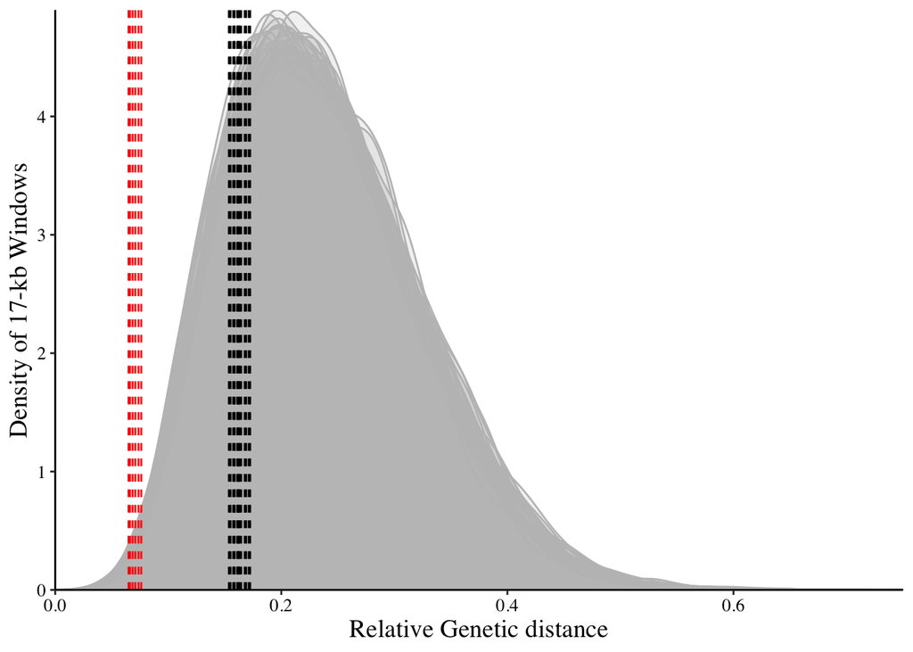

```r
selected_pairs <- c("ANSK7__POJA_4.cor", "ANSK8__POJA_4.cor", "ANSK01__POJA_4.cor", "CISK2__POJA_4.cor", "CISK3__POJA_4.cor", "CISK55__POJA_4.cor", "CHSK_MKP2451__POJA_4.cor", "GRSK_MKP1592__POJA_4.cor", "GRSK_MKP1593__POJA_4.cor", "ANSK7__POJA_IB2659.cor", "ANSK8__POJA_IB2659.cor", "ANSK01__POJA_IB2659.cor", "CISK2__POJA_IB2659.cor", "CISK3__POJA_IB2659.cor", "CISK55__POJA_IB2659.cor", "CHSK_MKP2451__POJA_IB2659.cor", "GRSK_MKP1592__POJA_IB2659.cor", "GRSK_MKP1593__POJA_IB2659.cor", "ANSK7__POJA_MKP1559.cor", "ANSK8__POJA_MKP1559.cor", "ANSK01__POJA_MKP1559.cor", "CISK2__POJA_MKP1559.cor", "CISK3__POJA_MKP1559.cor", "CISK55__POJA_MKP1559.cor", "CHSK_MKP2451__POJA_MKP1559.cor", "GRSK_MKP1592__POJA_MKP1559.cor", "GRSK_MKP1593__POJA_MKP1559.cor")

#This will plot distributions of POJA to all four skuas, overlapping
as.data.frame(dists_mttest) %>%
      tidyr::gather("pair", "distance", 4:length(dists_mttest)) %>%
      filter(pair %in% selected_pairs) %>% #
      filter(!grepl('chrZ', chromosome)) %>% #remove chrZ, since it might have different dynamics than autosomes
      ggplot(aes(xcolor = pair))+
      geom_density(aes(x=distance),alpha=0.2,colour="gray75", fill="gray75")+
      theme_classic()+ #simplify plot
      theme(axis.text.y = element_text(family="Times", face="plain", colour="black", size=10), axis.text.x = element_text(family="Times", face="plain", colour="black", size=10), axis.title.x = element_text(family="Times", face="plain", colour="black", size=14), axis.title.y = element_text(family="Times", face="plain", colour="black", size=14), legend.text = element_text(family="Times", face="italic", colour="black", size=10), legend.title = element_text(family="Times", face="plain", colour="black", size=12))+
      scale_x_continuous(expand = c(0, 0), limits = c(0, 0.75)) + #make sure that the origin is at 0,0
      scale_y_continuous(expand = c(0, 0), limits = c(0, NA))+
      xlab("Relative Genetic distance")+
      ylab("Density of 17-kb Windows")+
      geom_vline(xintercept = pomarinus_vs_southern, linetype="dashed", color = "black")+ #add a vertical line to mark the mtDNA observation
      geom_vline(xintercept = pomarinus_vs_Sskua, linetype="dashed", color = "red") #add a vertical line to mark the mtDNA observation
```

```r
#save the figure
#ggsave("mtDNA_vs_nuclear_divergence.pdf", width=3456, height=2234, units="px")
```

Finally, let’s calculate how much of the grey (nuclear) distribution falls below the black or red lines.

```r
#select which comparisons to look at
#selected_pairs <- c("ANSK7__POJA_4.cor", "ANSK8__POJA_4.cor", "ANSK01__POJA_4.cor", "CISK2__POJA_4.cor", "CISK3__POJA_4.cor", "CISK55__POJA_4.cor", "CHSK_MKP2451__POJA_4.cor", "GRSK_MKP1592__POJA_4.cor", "GRSK_MKP1593__POJA_4.cor")
#selected_pairs <- c("ANSK7__POJA_IB2659.cor", "ANSK8__POJA_IB2659.cor", "ANSK01__POJA_IB2659.cor", "CISK2__POJA_IB2659.cor", "CISK3__POJA_IB2659.cor", "CISK55__POJA_IB2659.cor", "CHSK_MKP2451__POJA_IB2659.cor", "GRSK_MKP1592__POJA_IB2659.cor", "GRSK_MKP1593__POJA_IB2659.cor")
#selected_pairs <- c( "ANSK7__POJA_MKP1559.cor", "ANSK8__POJA_MKP1559.cor", "ANSK01__POJA_MKP1559.cor", "CISK2__POJA_MKP1559.cor", "CISK3__POJA_MKP1559.cor", "CISK55__POJA_MKP1559.cor", "CHSK_MKP2451__POJA_MKP1559.cor", "GRSK_MKP1592__POJA_MKP1559.cor", "GRSK_MKP1593__POJA_MKP1559.cor")
selected_pairs <- c("ANSK7__POJA_4.cor", "ANSK8__POJA_4.cor", "ANSK01__POJA_4.cor", "CISK2__POJA_4.cor", "CISK3__POJA_4.cor", "CISK55__POJA_4.cor", "CHSK_MKP2451__POJA_4.cor", "GRSK_MKP1592__POJA_4.cor", "GRSK_MKP1593__POJA_4.cor", "ANSK7__POJA_IB2659.cor", "ANSK8__POJA_IB2659.cor", "ANSK01__POJA_IB2659.cor", "CISK2__POJA_IB2659.cor", "CISK3__POJA_IB2659.cor", "CISK55__POJA_IB2659.cor", "CHSK_MKP2451__POJA_IB2659.cor", "GRSK_MKP1592__POJA_IB2659.cor", "GRSK_MKP1593__POJA_IB2659.cor", "ANSK7__POJA_MKP1559.cor", "ANSK8__POJA_MKP1559.cor", "ANSK01__POJA_MKP1559.cor", "CISK2__POJA_MKP1559.cor", "CISK3__POJA_MKP1559.cor", "CISK55__POJA_MKP1559.cor", "CHSK_MKP2451__POJA_MKP1559.cor", "GRSK_MKP1592__POJA_MKP1559.cor", "GRSK_MKP1593__POJA_MKP1559.cor")

#determine how much of the distrinution is below the red line
a<-as.data.frame(dists_mttest) %>%
      tidyr::gather("pair", "distance", 4:length(dists_mttest)) %>%
      filter(pair %in% selected_pairs) %>% #
      #filter(!grepl('chrZ', chromosome)) %>% #
      filter(distance<=pomarinus_vs_Sskua_mean)%>%
      nrow()
#count total number of windows
b<-as.data.frame(dists_mttest) %>%
      tidyr::gather("pair", "distance", 2:length(dists_mttest)) %>%
      filter(pair %in% selected_pairs) %>% #
      #filter(!grepl('chrZ', chromosome)) %>% #
      nrow()
#get fraction
a/b
```

```
## [1] 0.004378763
```

```r
#0.004378763 with 17 kb windows, all pomarinus
#0.007550146 Alaskan
#0.004427058 IB2659
#0.004926108 4

#determine how much of the distribution is below the black line
a<-as.data.frame(dists_mttest) %>%
      tidyr::gather("pair", "distance", 2:length(dists_mttest)) %>%
      filter(pair %in% selected_pairs) %>% #
      #filter(!grepl('chrZ', chromosome)) %>% #
      filter(distance<=pomarinus_vs_southern_mean)%>%
      nrow()
#count total number of windows
b<-as.data.frame(dists_mttest) %>%
      tidyr::gather("pair", "distance", 2:length(dists_mttest)) %>%
      filter(pair %in% selected_pairs) %>% #
      #filter(!grepl('chrZ', chromosome)) %>% #
      nrow()
#get fraction
a/b
```

```
## [1] 0.2110821
```

```r
#0.2110821 with 17 kb windows, all pomarinus
#0.3129206 Alaskan
#0.2123378 IB2659
#0.2115812 4
```

A large portion of the genome (21%) falls below the black line, so the mitochondrial divergences between *S. pomarinus* and the southern hemisphere *Catharacta* are not different than expected based on nuclear divergence. However, very little (0.4%) of the genome falls below the red line, so the mitochondrial divergences between *S. pomarinus* and *S. skua* are lower than expected.

# Test directionality

The mitochondrial divergence between the *S. skua*/*S. pomarinus* clade and the southern hemisphere skuas is much older than the estimated divergence between *S. skua* and the southern hemisphere skuas, so we can reason that the direction of introgression was more likely from *S. pomarinus* into *S. skua*. However, incomplete lineage sorting can of course allow many gene trees to divergence earlier than the speciation event. But do the mitochondrial haplotypes diverge more deeply than expected under ILS? We can compare the mitochondrial estimate to the nuclear distribution.

```r
selected_pairs <- c("ANSK01__GRSK_MKP1592.cor", "ANSK01__GRSK_MKP1593.cor", "ANSK7__GRSK_MKP1592.cor", "ANSK7__GRSK_MKP1593.cor", "ANSK8__GRSK_MKP1592.cor", "ANSK8__GRSK_MKP1593.cor", "CHSK_MKP2451__GRSK_MKP1592.cor", "CHSK_MKP2451__GRSK_MKP1593.cor", "CISK2__GRSK_MKP1592.cor", "CISK2__GRSK_MKP1593.cor", "CISK3__GRSK_MKP1592.cor", "CISK3__GRSK_MKP1593.cor", "CISK55__GRSK_MKP1592.cor", "CISK55__GRSK_MKP1593.cor")

Sskua_vs_southern <- as.numeric(c("0.170114943", "0.162068966", "0.170114943", "0.170114943", "0.171264368", "0.172413793", "0.167816092", "0.170114943", "0.163218391", "0.170114943", "0.171264368", "0.170114943", "0.173563218", "0.168965517"))
Sskua_vs_southern_mean <- mean(Sskua_vs_southern)
Sskua_vs_southern_mean
```

```
## [1] 0.169376
```

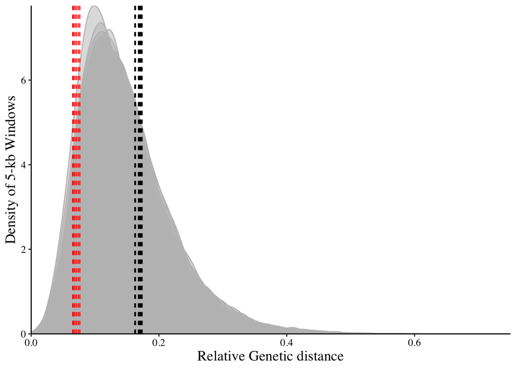

```r
#Then, plot these distributions
as.data.frame(dists_mttest) %>%
      tidyr::gather("pair", "distance", 4:length(dists_mttest)) %>%
      filter(pair %in% selected_pairs) %>% #
      filter(!grepl('chrZ', chromosome)) %>% #remove chrZ, since it might have different dynamics than autosomes
      ggplot(aes(xcolor = pair))+
      geom_density(aes(x=distance),alpha=0.5,colour="gray75", fill="gray75")+
      theme_classic()+ #simplify plot
      theme(axis.text.y = element_text(family="Times", face="plain", colour="black", size=10), axis.text.x = element_text(family="Times", face="plain", colour="black", size=10), axis.title.x = element_text(family="Times", face="plain", colour="black", size=14), axis.title.y = element_text(family="Times", face="plain", colour="black", size=14), legend.text = element_text(family="Times", face="italic", colour="black", size=10), legend.title = element_text(family="Times", face="plain", colour="black", size=12))+
      scale_x_continuous(expand = c(0, 0), limits = c(0, 0.75)) + #make sure that the origin is at 0,0
      scale_y_continuous(expand = c(0, 0), limits = c(0, NA))+
      xlab("Relative Genetic distance")+
      ylab("Density of 5-kb Windows")+
      geom_vline(xintercept = Sskua_vs_southern, linetype="dashed", color = "black")+ #add a horizonatal line to mark the mtDNA observation
      geom_vline(xintercept = pomarinus_vs_Sskua, linetype="dashed", color = "red") #add a horizonatal line to mark the mtDNA observation
```

```r
#determine how much of the distribution is below the black line
c<-as.data.frame(dists_mttest) %>%
      tidyr::gather("pair", "distance", 2:length(dists_mttest)) %>%
      filter(pair %in% selected_pairs) %>% #
      #filter(!grepl('chrZ', chromosome)) %>% #
      filter(distance>=Sskua_vs_southern_mean)%>%
      nrow()
#count total number of windows
d<-as.data.frame(dists_mttest) %>%
      tidyr::gather("pair", "distance", 2:length(dists_mttest)) %>%
      filter(pair %in% selected_pairs) %>% #
      #filter(!grepl('chrZ', chromosome)) %>% #
      nrow()
#get fraction
c/d
```

```
## [1] 0.3058741
```

The black line is higher than 69% of the distribution, lower than 31%. Since it falls within the overlap of the divergence between *S. skua* and the southern hemisphere skuas (on the upper end) and the divergence between *S. pomarinus* and the southern hemisphere skuas (on the lower end), the relative sequence divergence is not informative in this case.